# Kapitel 17 Elektrokonvulsiv terapi

## 17.1 Inledning

Under 1700-talet användes kamfer (utvunnet av bark från kamferträdet *Cinnamomum camphora*) för att inducera kramper i syfte att bota mani och psykos [268]. Detta prövades igen på 1930-talet [269]. Den första krampbehandlingen med elektricitet genomfördes 1938 [270].

Elektrokonvulsiv terapi (ECT) verkar genom att ett generaliserat krampanfall orsakas när ström leds genom hjärnan under några sekunder. Det epileptiska anfallet avslutar sig själv efter 30-60 sek. Behandlingen sker med läkemedel som ger muskelrelaxation under narkos [271].

## 17.2 Indikationer

Rekommenderas som förstahandsbehandling vid svår (unipolär eller bipolär) depression med psykos, post-partum psykos, cycloid psykos, katatoni (oavsett bakomliggande diagnos), och malignt neuroleptikasyndrom. Kan övervägas som förstahandsbehandling vid svår depression utan psykos, manisk episod med eller utan psykos, och post-partum depression [271]. Vid malign katatoni eller deliriös mani kan ECT ha en snabb och livräddande effekt [271]. De olika indikationerna beskrivs mer i detalj nedan.

### 17.2.1 Kontraindikationer och riskvärdering

Några absoluta kontraindikationer finns inte. Intrakraniellt tryck ökar, men konsensus är att ECT är säkert vid små solitära tumörer som inte ger masseffekt, ödem eller ökat intrakraniellt tryck. Vid nylig ischemisk stroke är komplikationsrisken låg. [271]

#### 17.2.1.1 Hjärt-kärlsjukdom

Hjärtat utsätts för fysiologisk belastning, varför ischemisk hjärtsjukdom (särskilt hjärtinfarkt de senaste 6 månaderna), hjärtsvikt och arytmier bör vägas in i risk-nytta-analysen. Kortverkande betablockare (tex labetalol) kan reducera belastningen på hjärtat. QTT är prediktor för arytmi under ECT. Vid förmaksflimmer bör adekvat antikoagulation ha förelegat minst en månad. Kardiell pacemaker är inget hinder men den bör ställas om till asynkront läge för att skyddas från inferens från ECT-behandlingen. Om patienten har implanterabar defibrillator bör den stängas av under ECT och behandlingen ges med EKG-övervakning och beredskap för extern defibrillering. Pacemaker utgör inget hinder.

ECT bör undvikas vid instabil eller allvarlig hjärt-kärlsjukdom samt inom fyra veckor efter hjärtinfarkt.

#### 17.2.1.2 Sjukdom i CNS

Ökad risk vid tillstånd med eller risk för ökat intrakraniellt tryck (t.ex. aneurysm med risk för ruptur, färsk stroke, vissa hjärntumörer). Det finns en viss ärftlighet för intrakraniella aneurysm varför hereditet för hjärnblödning bör ingå i anamnesen.

#### 17.2.1.3 Samtidig läkemedelsbehandling

Teofyllin kan ge ökad risk för förlängd kramp och status epilepticus.

#### 17.2.1.4 Övriga tillstånd

- Grav osteoporos.
- Mycket dålig tandstatus som bör föranleda särskild omsorg att uppnå fullgod muskelrelaxering.
- Nedsatt lungfunktion såsom vid KOL, astma, pneumoni.
- Glaukom.
- Övriga tillstånd med förhöjd narkosrisk.

### 17.2.2 Depression

Undernäring, utmattning och dehydrering till följd av depression stärker indikationen, liksom psykotiska symtom, eftersom behandlingseffekten av antidepressiva är lägre i dessa fall. Samsjuklighet med ångestsyndrom tycks inte påverka effekten av ECT. Dock bör tydliga depressiva symtom finnas för att ECT skall vara aktuellt. Vid bipolär depression är remissionsgraden är som vid unipolär depression. Vissa faktorer är i observationsstudier förknippade med bättre eller sämre effekt av ECT (se listorna nedan).

Jämfört med svår depression har ECT mindre effekt vid medelsvår depression som också är förknippat med mer upplevda biverkningar. Vid svårbehandlad depression (> 6 mån farmaka utan effekt) svarar 45% på ECT jämfört med 90% vid svår depression eller depression med psykos [272,273].

Återfallsrisken efter en ECT-serie är hög. Vid svår depression återfaller hälften inom ett år, vilket kan ske snabbt [271]. Detta motiverar tät uppföljning under första året och kan föranleda fortsättnings-ECT.

Faktorer som är förknippade med särskilt god efekt av ECT [274]:

- Melankoliska drag
- Uttalad psykomotorisk hämning
- Psykotiska symtom [275]
- Högre ålder [275]

Faktorer som är förknippad med sämre effekt av ECT:

- Personlighetssyndrom (Något lägre responsandel och ökad återfallsrisk) [276]
- Mer långvarig depression
- Utebliven effekt av läkemedel
- Personlighetssyndrom:
- Beroendesyndrom (något lägre responsandel och ökad återfallsrisk)
- Låg ålder

### 17.2.3 Mani

Förkortar maniska skov. Lika effektivt som litium med remission hos 50%. ECT rekommenderas när läkemedelsbehandling varit otillräckligt eller ej tolereras. Även effektivt vid mixed state. Rekommenderas vid deliriös mani, då daglig behandling bed bilateral elektrodplacering tills et akuta tillståndet gått över.

### 17.2.5 Katatoni

Respons hos 90%. Vanligen snabb effekt. Positiva prediktorer är typiska symtom såsom waxy flexibility, gegenhalten. Rekommenderas vid exciterad katatoni och malignt neuroleptikasyndrom. Ges med fördel tidigt i förloppet för att minska mortalitet. Kan ges samtidigt som bensodiazepinbehandling. Behandlingen ges vanligen dagligen tills tillståndet har hävts.

### 17.2.6 Övriga tillstånd som kan behandlas med ECT

Cykloid psykos. Post-partum psykos.

### 17.2.7 Överväganden

Överväg: Symtomens svårighetsgrad, suicid- och våldsrisk, tidigare utebliven effekt av psykoterapi och läkemedel, tidigare respons på ECT, tolerans för fortsatt läkemedelsbehandling.

Risker: Kardiovaskulär sjukdom.

### 17.2.8 ECT vid graviditet och amning

Risken för förtidsbörd ökar om ECT ges under senare delen av graviditeten. Risker i samband med sövning föreligger också. Behovet av ECT bör vägas mot detta. Post-partum är ECT en rekommenderad behandling vid psykos eller djup depression.

Vid graviditet bör förberedelserna inkludera gynekologisk undersökning, avbrytande av antikolinerg medicinering, intravenös hydrering, antacid behandling, och tocodynamometri. Under ECT-behandlingen lägges den högra höften högt, fostret övervakas, intubation görs, och överdriven hyperventilering undviks.

### 17.2.9 ECT för barn

Kan användas som förstahandsalternativ vid malignt neuroleptikasyndrom; svår katatoni till följd av psykos, autism, eller affektiv episod; uttalad psykos till följd av schizofreni, depression eller mani. Vanligen provas först bensodiazepiner respektive antipsykosika medel. Socialstyrelsen avråder från ECT vid ålder < 12 år. Övervägs dock vid exciterad katatoni vid autism (exv repetitivt monotont självskadebeteende).

## 17.3 Effektivitet

Verklig ECT är mer effektivt än simulerad ECT (Standardiserad effektstorlek -0.91, 95% CI -1.27 till -0.54) [274]. Detta motsvarar ca 10 poängs förbättring på Hamilton depresssion rating scale (HDRS). ECT är även mer effektivt än läkemedelsbehandling, med ca 10 p skillnad på HDRS [274]. Högre elektrisk dos och bilateral elektrodplacering ger bättre effekt på depressiva symtom, men kan vara förknippat med mer kognitiva biverkningar [274].

Återfallsrisken är ca 50% utan återfallsförebyggande behandling.

## 17.4 Biverkningar

De vanligaste biverkningarna illamående, huvudvärk, och muskelvärk beror främst på anestesin.

**Lista**. Vanliga biverkningar och åtgärder.

- Huvudvärk: Suppositorium med analgetika före behandlingen eller peroralt efter behandlingen.
- Muskelvärk: Dosökning av muskelrelaxerande medel kan övervägas men observera att medlet har muskelvärk som biverkan.
- Illamående: Vid kraftigt illamående kan antiemetika ges i samband med anestesin.

Risken för allvarliga biverkningar är ungefär 1 på 10 000 behandlingar och en nylig genomgång av ca 100 000 behandlingar visade ingen ökad risk för död.

**Lista.** Allvarliga biverkningar

- Aspiration under narkosen.
- Bradykardi, asystoli pga kraftig sympaticusaktivering. Antikolinergikum kan ges när risken för bradyarytmi bedöms ökad.
- Aneurysmruptur pga kraftig blodtrycksstegring. Reglera blodtrycket.

### 17.4.1 Konfusion i anslutning till behandlingen

Ökad risk med bilateral elektrodplacering, hög strömstyrka, otillräcklig oxygenering, förlängd kramptid. Högre ålder eller bakomliggande neurologisk sjukdom ger ökad risk för svårare och mer långvariga besvär. Vid delirium bör ECT-serien avbrytas och om besvären då fortsätter bör utredning av annan orsak (tex hjärntumör) göras.

### 17.4.2 Minnesproblem

Åtgärder vid konfusion eller minnesproblem kan vara att ändra elektrodplacering (till unilateral om bitemporal använts?), strömdos, behandlingsintervall, anestesimetod och samtidig läkemedelsbehandling [på vilket sätt?] [271].

### 17.4.3 Postiktal agitation

Desorientering, motorisk rastlöshet, panik och agressivitet. Uppträder hos 5-10%.

### 17.4.4 Minnesproblem

Prognos: Besvären går över efter < 6 månader efter behandling. Kvartående minnesstörningar efter 6 mån är inte att förvänta och bör utredas. Demens? Tänk även på att text bensodiazepiner och valproat påverkar minnet.

Minnesbortfall kan påverka självkänsla tex vid kommunikation med andra, hantera detta genom att ge stöd även vid uppfölning. Informera även anhöriga om att övergående anterograda minnesstörningen och luckor kan förväntas (exv vid permission, var saker står, dörrkod etc).

Använd CPRS för att mäta minnesbesvär.

### 17.4.5 Kardiovaskulära biverkningar

ECT ger fysiologisk belastning på hjärtat. Den elektriska stimuleringen ger parasympaticuspåslag vilket bromsar hjärtfrekvensen. Detta följs av ett sympaticuspåslag med ökade katekolaminnivåer som har maximum ca 3 minuter efter start av kramperna. Därefter dominerar åter parasympaticuspåslaget i 5-10 minuter, vilket kan ge övergående bradycardi och övergående asystoli, en risk som är ökad om stimuleringen inte ledde till kramp.

## 17.5 Metod

ECT ges vanligen först som “indexserie”, dvs att behandlingen ges tills symtomfrihet inträder, vanligen tre gånger per vecka vid totalt 4-12(-20) tillfällen beroende på behandlingssvar. Om effekten varit tydlig kan indexserien ibland förlängas med “fortsättnings-ECT” under max sex månader med glesare intervall, vars syfte är att bibehålla behandlingssvar och förebygga återfall. Därefter kan även “underhålls-ECT” ges, där syftet är att förrebygga återkommande sjukdomsskov [271].

**Lista**. Variabler vid stimuleringstillfället som kan ha betydelse för behandlingseffekt.

- Elektrodplacering
- Laddningsdos
  - Stimuleringstid
  - Strömstyrka
  - Pulsfrekvens
  - Pulsbredd
- Anestesimetod
- Samtidig läkemedelsbehandling

### 17.5.1 Den elektriska stimuleringen

Att det epilepsianfall som utlöses av ECT är generaliserat är viktigt för behandlingseffekten. Icke-generaliserade anfall har mindre terapeutisk effekt [271].

#### 17.5.1.1 Tillförd strömdos

Kramptröskeln är individuell och beror av faktorer som ålder, kön, medicinering och sjukdom [271]. Denna kan titreras fram, men för att förkorta tiden i narkos börjar man i praktiken med en strömdos baserad på en teoretisk beräkning som vanligen utläses från en tabell som beror på apparatur och där ålder och kön tas med som variabler.

Vid första behandlingen utgår man från den rekommenderade strömdosen och gör modifikationer utifrån tex ålder, medicinering, den psykiska sjukdomens svårighetsgrad mm. Alternativt ges en standardordination vid första behandlingen. Utvärdera tidigare strömdos vid varje behandlingstillfälle och justera fortlöpande.

**Lista**. Variabler som har betydelse för kramptröskeln [270].

- Kön: Män har högre kramptröskel.
- Ålder: Högre ålder ger högre impedans och därmed behov av högre laddningsdos
- Medicinering: Olika läkemdel kan höa eller sänka kramptröskeln.
- Typ av anestesi.
- Tidpunkt för stimulering i relation till narkosdjup
- Tillståndets svårighetsgrad
- Elektrodplacering

> **Tips**. Ge behandlingen tidigast efter tre minuters sedering, då det antas vara lättare att utlösa krampanfallet i uppvakningsfasen än insomningsfasen. Om det epileptiska anfallet är svårutlöst, stimulera när sederingen börjar avta.

Tillförd strömdos, sk “ladningsdos”, mäts i coulomb (C) och beräknas som strömstyrka (A) x tid (s). Tid är här pulsbredd (s) x antal pulser per sekund (Hz) x total stimuleringstid (s). Detta innebär i praktiken att ca 10% av total stimuleringstid är aktiv stimulering med tillförsel av elektrisk ström. Notera att med bidirektionella pulser (vilket är standard), blir antalet pulser per sekund dubbla pulsfrekvensen.

> **Exempel**. Beräkning av tillförd strömdos. 0,8 A x [140 (antal pulser vid frekvens 70 Hz) x 0,5 x 10^-3 (pulsbredd i sekunder) x 6 (total stimuleringstid i sekunder) s] = 0,8 A x 0,42 s = 0,336 As = 336 mC. Exemplet är hämtat från [271].

Med apparaturen “Thymatron” ställs dosen in i procent, där 200% är maximum och motsvarar 1000 mC. Strömstyrkan är alltid 900 mA och övriga variabler ställs in automatiskt av apparaten [efter att den uppmätt impedans?]. Med apparaturen “MECTA” anges variablerna separat.

**Lista**. Apparatvariabler och intervall.

- Strömstyrka: 0.8-0.9 A
- Pulsbredd: 0.3-1 ms
  - Ultrakort (ultra brief pulse): 0.3-0.5 ms
  - Kort: 0.5-1.5 ms
- Pulser per sekund: 70 Hz (ger 140 pulser/sekund)
  - Kan vara mellan 30-120 Hz
- Total stimuleringstid: 4-6 sek vid pulsbredd 0.5-1 ms

Notera att äldre apparatur använde sinusvågor som troligen gav minst 1.5 gånger större krampinducerande effekt [271], vilket kan ha betydelse vid värdering av tidigare forskning.

#### 17.5.1.2 Pulsbredd

Bidirektionella pulser med kort pulsbredd (0.5-1 ms) är standard [271].

Ultrakort pulsbredd (0.3-0.5 ms) kräver lägre tillförd strömdos för att utlösa krampanfall, men ger i högre grad krampanfall som ej är helt generaliserade och lägre effektivitet i behandlingen. En potentiell fördel, som dock inte påvisats konsekvent, är minskade kognitiva biverkningar [271]

#### 17.5.1.3 Elektrodplacering

**Bitemporal elektrodplacering:** Elektroderna placeras bilateralt 3-4 cm ovan mittpunkten på en linje mellan tragus och yttre ögonvrån.

**Unilateral elektrodplacering (right unilateral, RUL eller “placering enligt d’Elia”):** Ges över dominant hemisfär (vanligen höger sida både vid höger- och vänsterhänthet). Den högra elektroden placeras som vid bitemporal metod och den andra på vertex på samma sida (3 cm lateralt om medellinjen/sutura sagittalis i linje med tragus).

**Bifrontal elektrodplacering:** Liknar bitemporal men är mindre undersökt och bör därför främst användas i forskningssammanhang.

Unilateral placering kräver högre laddningsdos och ger längre tid till effekt (längre behandlingsserier), men minskar risken för akut konfusion och anterograd amnesi, jämfört med bilateral placering [271].

Unilateral placering är standard i Sverige. Vid uteblivet behandlingssvar efter 6-12 behandlingar kan bitemporal elektrodplacering övervägas [271]. När snabb effekt är avgörande (exempelvis vid stuporös katatoni eller deliriös mani?) kan bitemporal metod vara att föredra.

#### 17.5.1.4 Monitorering under ECT-behandling

EEG-elektroder sätts bifrontalt och på nyckelbenet. EKG-övervakning och pulsoximeter (för kontinuerlig monitorering av puls och saturation) kopplas, liksom blodtrycksmaschett.

**Lista**. Parametrar som observeras och registreras under behandlingen:

- Blodtryck före och efter behandling.
- Maxpuls under behandling
- Den motoriska krampens mönster (förlopp, utbredning, symmetri, duration)
- EEG-aktivitet (symmetri, krampens duration, postiktal suppression)

**Lista**. Variabler för bedömning krampens kvalitet

- Tid för motorisk aktivitet (> 20–30 sekunder).
- Tid för epileptisk aktivitet (upp till 10–20 sekunder längre än motorisk aktivitet).
- Kvaliteten på det motoriska anfallet (tecknen begränsas av muskelrelaxantia men kan ofta observeras)
  - Initial tonisk fas
  - Successivt övergående i en symmetrisk tonisk-klonisk fas
  - Avslutas distalt till proximalt med avtagande frekvens
  - Notera eventuell sidoskillnad
- Kvaliteten på EEG-mönstret
  - Rekryteringsfas
  - En fas med intensiv epileptisk aktivitet som successivt förlångsammas
  - Övergår i mer långsamma vågor.
  - Dessa upphör distinkt och övergår i en postiktal suppression (ett rakt streck på EEG).
- Kardiovaskulär respons (kan hämmas av beta- receptorblockerare)
  - pulsstegring under krampanfallet (> 120)
  - Blodtrycksstegring efter anfallet
- Postiktal dåsighet och gradvis återhämtning av orienteringen.

Efter bahandlingen kontrolleras puls och blotryck regelbundet tills patienten är helt vaken. Syrgas tillförs. Före hemgång kontroll av vakenhet, orientering, och klarhet.

#### 17.5.1.5 Behandling vid krampanfall av otillräcklig aktivitet

Om man inte uppnår ett krampanfall med god kvalitet benämns det abortivt anfall. Då kan restimulering efter 40-60 sekunder göras med högre dos (tex dubbel) eller byte till bitemporal elektrodplacering.

#### 17.5.1.6 Komplikationer under behandlingstillfället

**Utdragen kramp.** Ett anfall som inte upphör av sig själv bör avslutas efter 180 sekunder. Förbered för detta efter 120 sekunders epileptisk aktivitet. Ordinera intravenöst 2-5 ml propolipid (10 mg/ml) eller 1-4 ml diazepam (5 mg/ml). Tillse adekvat saturation och cirkulation. Vid status epilepticus ordinera diazepam och förbered flytt till intensivvården.

**Motorisk oro i samband med uppvaknandet.** Kontrollera saturation. Bedöm orsaker till oro. Vid behov kan 1-3 ml propolipid (10 mg/ml) eller 1-2 ml diazepam (mg/ml) ges.

**Blodtrycksstegring** efter behandling. Normaliseras vanligen utan åtgärd.

### 17.5.2 Checklista för ECT-administration

Första behandlingen ges vanligen enligt standardinställningar:

- Elektrodplacering: Unilateral
- Pulsbredd: 0.5 ms
- Frekvens: 70 Hz
- Stimuleringstid: 4 s
- Strömstyrka: 800 A

= 224 mC

Receptet modifieras utifrån tillståndet, exempelvis vid behov av snabb effekt kan man börja med bitemporal elektrodplacering eller högre strömdos. Vid kramp av otillräcklig kvalitet ges restimulering, varvid man antingen byter från unilateral till bitemporal elektrodplacering eller höjer strömdosen till ungefär det dubbla genom att exempelvis förlänga pulsbredden till 0.7-1 s.

Läkemedel som ges i samband med behandlingen är vanligen:

- Glykopyrron (Robinul®) 0.1 mg , antikolinergikum mot slem i luftvägarna, ges om slembildning varit ett problem vid första behandlingen.
- Thiopental (Pentocur®) 3-6 mg/kg, narkosmedel, vid ECT vanligen i det lägre doseringsintervallet.
- Propolipid (Propofol®) ca 2 mg/kg, narkosmedel, höjer kramptröskeln.
- Celocurin (Suxametonium®), 1 mg/kg, muskelrelaxerande, 0.3-0.8 mg/kg ger total avslappning under 5-10 minuter.

#### 17.5.2.1 Lista behandlingsförfarande

Förberedelser:

- Glykopyrron om detta skall ges
- Analgetika om detta skall ges
- Antihistamin om tidigare histaminerg reaktion på tiopental

Vid start:

- Blodtryck och puls
- Koppla EEG-elektroder
- Klistra på namnetikett på EEG-remsan
- Applicera elektrodgel på ECT-plattorna (grå höger, brun vänster, grön på nyckelbenet)
- Lägg fram bettkudde
- Preoxygenering

Förlopp:

1. Narkosmedel injiceras. Starta timer (= 0 s). Pausa larm.
2. Narkosdjup kontrolleras. Frånvaro av motorisk aktivitet och verbal respons räcker. Vid osäkerhet kontrolleras blinkreflex.
3. Muskelrelaxerande injiceras (vid 40 s om tiopental givits, 60 s om propolipid givits).
4. Bettkudde appliceras.
5. Kontrollera att fascikulationer från muskelrelaxerande har upphört och att bettkudde applicerats.
6. Stimulera (vid 2 min 40 s om tiopental; 3 min om propolipid).
7. Observera:
- Motorisk kramp: Utbredning, symmetri, duration (markera på EEG-remsan)
- Maxpuls enligt ekg-monitor eller pulsoxymeter
8. Kontrollera EEG och bedöm krampens kvalitet.
9. Blodtryck och puls vid avslut.

Efter:

- Observation och oxygenering
- Dokumentation

## 17.6 Behandlingsintervall och seriens längd

### 17.6.1 Indexserien

Vanligen ges behandlingen tre gånger per vecka under indexserien. Två gånger i veckan är lika effektivt och ger mindre kognitiva biverkningar, men också långsammare förbättring. Det behövs i medeltal 5-12 (M 7) behandlingar för att behandla en depressiv episod.

### 17.6.2 Antal behandlingar per vecka

Vanligast är tre behandlingar per vecka med totalt 4-12 behandlingstillfällen. Vid tillstånd som ökar risken för konfusion (tex hög ålder) kan 1-2 behandlingar per vecka vara att föredra. Vid akuta livshotande tillstånd kan behandlineg ges dagligen och glesas ut när de mest mest akuta symtomen har hävts.

### 17.6.3 Fortsättnings-ECT och underhålls-ECT

Indexserien ibland förlängas med “fortsättnings-ECT” under max sex månader med glesare intervall, vars syfte är att bibehålla behandlingssvar och förebygga återfall.

ECT ges en gång per vecka till en gång per månad i upp till sex månader, där gradvis utglesning är en metod som använts.

Om symtom återkommer kan tätare behandling eller ny indexserie övervägas. Vid partiell respons eller snabbt återinsjuknande (några dagar) bör man överväga att avsluta behandlingen.

Med syfte att förebygga återkommande sjukdomsskov kan behandlingen förlängas bortom sex månader efter indexserien, sk “underhålls-ECT”. Vanligen ges då ECT varannan till var fjärde vecka, ibland en gång per vecka. Intervallet anpassas beroende på tolerans och effekt. Behandlingen bör utvärderas regelbundet men någon bortre gräns för antalet behandlingar finns ej. Det finns ingen vetenskapligt befäst bortre gräns för antal behandlingar, och några hjärnskador ses ej på DT efter behandling, MEN epilepsi kan ge glios. Post-mortem studier fallbeskrivingar visar dock inga histologiska tecken på skada av ECT. [Pia Nordanskog, Kurs]

## 17.7 Återfallsförebyggande behandling

Efter ECT som getts vid personens första insjuknande i depression rekommenderas antidepressivt läkemedel. Vid återkommande depressioner som behandlats med ECT rekommenderas antidepressiva i kombination med litium. Återfallsrisken med fortsättningsbehandling [och underhållsbehandling?] är den samma som vid behandling med litium och nortiptylin. Vid recidiv trots läkemedelsbehandling eller efter särskilt svåra episoder (tex betydande sucidrisk) rekommenderas fortsättnings-ECT i kombination med både litium och ett antidepressivt läkemedel. Antipsykotiska läkemedel kan ges vid psykotsik depression. [271]

Vid bipolärt syndrom rekommenderas i första hand litium, vilket kan kombineras med tex SSRI, nortriptylin, kvetiapin eller lamotrigin [271]. Indikationen för fortsättnings-ECT är som vid unipolär depression.

### 17.7.1 Samtidig läkemedelsbehandling

Kramphämmande: Bz, propofol, lamotrigin.

#### 17.7.1.1 Tricykliska antidepressiva

TCA bör sättas ut pga risk för arytmi.

#### 17.7.1.2 SSRI och SNRI

#### 17.7.1.3 Litium

Äldre fallrapporter väckte misstanke om att samtidig litiumbehandling kunde vara förknippat med ökad risk för förlängd kramptid, kognitiva biverkningar och långsammare uppvakning från anestesi. Senare studier har dock visat att samtidig litiumbehandling är säkert.

Tumregel: Håll litiumkoncentrationen i den lägre delen av målintervallet, eller hoppa över kvällsdosen dagen innan ECT.

#### 17.7.1.4 Bensodiazepiner

Kan försvåra induktion av kramp och bör därför minskas eller sättas ut.

#### 17.7.1.5 Antiepileptika

Om dessa används för psykiatriska diagnoser bör de sättas ut eller sänkas. Vid epilepsi bör de hållas oförändrade, varvid man istället kan behöva höja stimulusintensiteten och ge ECT med bilateral elektrodplacering.

## 17.8 Uppföljning och utvärdering av behandlingen

Behandlingsmålet är i allmänhet symtomfrihet. Remission sker vanligen efter 4-12 behandlingar. Regelbundna skattningar med Clinical Global Impression (CGI) och Montgomery Åsberg Depression Rating Scale (MADRS) eller liknande skattningsskalor rekommenderas. Bedöm även effekten på psykomotorik och interaktion med omgivningen.

Vid utebliven/tveksam effekt: 1. Har krampresponsen varit god? - Om inte, har optimering av strömdosen och bitemporal placering provats? 2. Finns faktorer som hindrar tillfrisknande? - Exempel? 3. Förnyad diagnostisk bedömning. - Vid omvårdering av diagnosen, föreligger fortfarande indikation för ECT? 4. Överväg avslut om fortsatt behandling bedöms ge otillräcklig effekt jämfört med risker och biverkningar.

Vid kortvarig effekt: - Överväg underhållsbehandling om ECT har varit effektivt. - Överväg avslut om effekten varit endast några dagar [?]. - Överväg avslut vid tveksam behandlingseffekt efter ca 12 behandlingar av god kvalitet.

Vid kognitiva besvär som bedöms bero på ECT-behandlingen: - Använd så låg strömdos som möjligt. Byte av anastetikum samt seponering av läkemedel som höjer kramtröskeln kan möjliggöra detta. Tid mellan narkosens start och stimulering kan förlängas. Hyperventilering i samband med narkos. - Överväg unilateral stimulering. - Överväg kortvågsteknik. [?] - Värdera behandlingseffekt mot graden av biverkningar.

Eftersfråga och testa minnesproblem [Hur?]. Om problem kvarstår bortom några veckor efter behandlingens avslut bör fördjupad utredning göras [vad?]. Bedöm om kvarvarande psykiska besvär, samtidig läkemedelsbehandling eller kan vara bidragande. [? Överväg om demens, alkoholöverkonsumtion, hjärntumör etc? kan föreligga]. Vid minnessvårigheter som bedöms bero på kvaravarande psykiska besvär kan fortsatt ECT-behandling vara av värde.

Vid kortvarig effekt - Undvik onödig behandling eller ge underhållsbehandling?

Uppföljning sex månader efter index-ECT rekommenderas [271].

### 17.8.1 Återfallsrisk

Risken för återfall vid affektivt sjukdomsskov är högst 2-4 veckor efter avslutad behandling och är fortsatt hög i minst sex månader. Hälften återfår symtom inom 1-2 år.

Riskfaktorer för återfall efter avslutad ECT

- Kvarvarande symtom efter ECT
- Läkemedelsbehandling overksam
- Bensodiazepinbehandling
- Beroendesyndrom

## 17.9 Information till patient och anhöriga

- Informera om förväntade minnesbesvär

## 17.10 Resurser

SPF Kliniska riktlinjer, ECT [271].

American Psychiatric Association (1978). Report on the task force on electroconvulsive therapy. Washington, DC, APA. [277]

American Psychiatric Association (2001). A task force report on the practice of electroconvulsive therapy; recommendations for treatment, training and privileging. Washington DC, American Psychiatric Association (APA). [278]

[Blog om ECT](https://ectpsych.blogspot.com/)

## 17.11 Definitioner

**Reobas och kronaxi** är mått på excitabiliteten i en cell eller vävnad (**Figur 17.1**). Inom neurovetenskap är reobas den minsta amplitud av ström som vid oändlig duration (i praktiken ca 300 ms) utlöser depolarisation av cellmembranet. Kronaxi är den duration under vilken elektrisk ström med amplitud motsvarande dubbla reobasen måste appliceras för att utlösa depolarisation (i praktiken ca 0.2 ms).

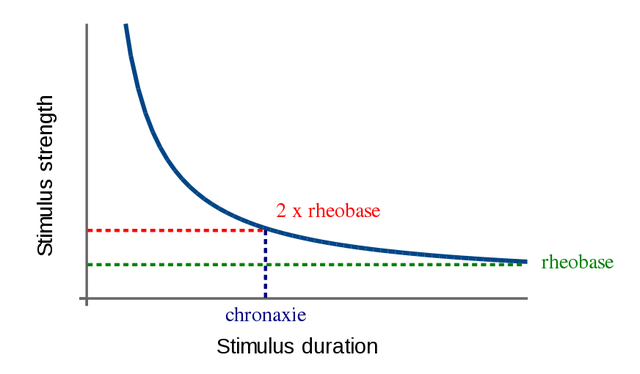

Figur 17.1: Reobas och kronaxi.